# EEC 214 Lecture 1 Notes

Rajeevan Amirtharajah

ramirtha@ucdavis.edu

(c) Rajeevan Amirtharajah, 2026

# Python Initialization

```python
# --------------------------------------------------------------------
# Initialization
# --------------------------------------------------------------------

import matplotlib.pyplot as plt     # MATLAB-style plotting

import numpy as np                  # Numerical methods
from numpy import sqrt, sin, cos, tan, pi, log, e, exp, arctan, arcsin, arccos, log10, log2
from numpy import zeros, ones, linspace, geomspace, logspace
from numpy import real, imag

from scipy import signal            # Signal processing toolbox
```

# Typical Device Parameters

Taken from Sedra and Smith, Microelectronics, 8th ed.

[figure not shown]

Early voltage $|V_{A}| = |V_{A}^{'}|L$

[figure not shown]

# INTEGRATED CIRCUIT DESIGN FOR POWER ELECTRONICS

Primary focus on DC/DC conversion

## VOLTAGE CONVERTER

**Model converter as a two-port:**

- **Port 1 (Left):** Voltage $V_1$, Current $I_1$ (arrow pointing right, into the converter)
- **Port 2 (Right):** Voltage $V_2$, Current $I_2$ (arrow pointing left, into the converter)

**Convention: (PMIC Applications)**

- **Input Port (Left):** Voltage $V_{IN}$, Current $I_{IN}$ (arrow pointing right, into the converter)
- **Output Port (Right):** Voltage $V_{OUT}$, Current $I_{OUT}$ (arrow pointing right, out of the converter)

[figure not shown]

**Input Power**

$$P_{IN} = V_{IN} \cdot I_{IN}$$

**Output Power**

$$P_{OUT} = V_{OUT} \cdot I_{OUT}$$

**Efficiency**

$$\eta = \frac{P_{OUT}}{P_{IN}} \le 1.0 \quad (100\%)$$

**Converter Losses** $P_{LOSS}$:

$$P_{OUT} + P_{LOSS} = P_{IN}$$

**Rewriting Efficiency:**

$$\eta = \frac{P_{OUT}}{P_{OUT} + P_{LOSS}} \implies \eta P_{LOSS} = (1-\eta) P_{OUT}$$

Most losses are dissipated as **heat**, some losses due to electromagnetic radiation.

$$P_{LOSS} = \left(\frac{1-\eta}{\eta}\right) P_{OUT} = \left(\frac{1}{\eta} - 1\right) P_{OUT}$$

Maximizing $\eta$ is equivalent to minimizing losses.

Consider the following example.

Assume:

- $P_{OUT} = 127\ \textrm{mW}$
- $P_{LOSS} = 17.9\ \textrm{mW}$

```python
Pout  = 127
Ploss = 17.9

print("Efficiency = {0:7.3f} (%)".format(100*(Pout/(Pout + Ploss))))
```

```
Efficiency =  87.647 (%)
```

```python
# Decrease losses by 10X
Ploss = 17.9/10

print("Efficiency = {0:7.3f} (%)".format(100*(Pout/(Pout + Ploss))))
```

```
Efficiency =  98.610 (%)
```

# DC-DC Converter Architectures

1. Linear Regulator
2. Switching Converter (Inductor-Based)
3. Switched Capacitor Converter

Example: Assume 100 V DC input, 5 $\Omega$ (resistive) load, desired 50 V DC output.

[figure not shown]

Find $I_{OUT}$ and $P_{OUT}$ assuming $V_{OUT} = 50\ \textrm{V}$:

$$I_{OUT} = \frac{V_{OUT}}{5\ \Omega} = \frac{50\ \textrm{V}}{5\ \Omega} = 10\ \textrm{A}$$$$P_{OUT} = V_{OUT} \cdot I_{OUT} = (50\ \textrm{V})(10\ \textrm{A}) = 500\ \textrm{W}$$

Find $I_{IN}$? Need more information, but we can use conservation of energy (i.e., efficiency $\eta$) to calculate a lower bound on $I_{IN}$.

$$P_{IN} = I_{IN} \cdot V_{IN} \geq P_{OUT} \Rightarrow I_{IN} \cdot (100\ \textrm{V}) \geq (50\ \textrm{V})(10\ \textrm{A}) \Rightarrow I_{IN} \geq 5\ \textrm{A}$$

Always a good idea to sanity check input/output power and current!

```python
VIN  = 100 # (V)
VOUT =  50 # (V)
RL   = 5   # (ohms)
```

**1. Linear Regulator**

[figure not shown]

To set $V_{OUT} = 50\ \textrm{V}$, voltage divider with $R_S = 5\ \Omega \Rightarrow$

$$I_{IN} = I_{OUT} = 10\ \textrm{A} \geq 5\ \textrm{A} \quad \checkmark$$$$P_{IN} = V_{IN} \cdot I_{IN} = (100\ \textrm{V})(10\ \textrm{A}) = 1000\ \textrm{W}$$$$\eta = \frac{P_{OUT}}{P_{IN}} = \frac{500\ \textrm{W}}{1000\ \textrm{W}} = 50\%$$

What happens if we want $V_{OUT} = 50\ \textrm{V}$ when $V_{IN}$ changes? Or $R_L$ deviates from $5\ \Omega$?

Need to adjust $R_S$! Could manually tune the potentiometer... but circuit with feedback is much better!

Example above is a **series** regulator, can also utilize a **shunt** regulator.

[figure not shown]

What is the voltage drop (drain-source) across $M0$?

$V_{DS}$ = 50 V

What is the current through $M0$?

$I_{DS} = I_{OUT}$ = 10 A

What is the equivalent resistance of $M0$?

$$R_{DS} = \frac{V_{DS}}{I_{DS}} = 5\ \Omega$$

What is the efficiency?

$\eta \leq$ 50%

(Must be less than 50% due to opamp power consumption, $V_{REF}$ generator, protection circuits, etc.)

**2. Switching Converter**

Efficiency of linear regulator limited by $V_{OUT} / V_{IN}$ ratio. Let's try to improve efficiency.

Idea: If $V_{IN}$ was an AC source, we can use a transformer.

[figure not shown]

$$\frac{v_{in}}{N_1} = \frac{v_{out}}{N_2} \Rightarrow v_{out} = \frac{N_2}{N_1} v_{in} \Rightarrow \text{if } N_1 = 2 N_2, \ v_{out} = \frac{v_{in}}{2} = 50\ \text{V} \sin(2\pi 60 t)$$

Amplitude 50 V is the peak voltage, not the average.

The output voltage is not DC!

But, if transformer is ideally linear and lossless, then $I_{out} = 10\ \text{A} \sin(2\pi 60 t)$ and $I_{in} = 5\ \text{A} \sin(2\pi 60 t) \Rightarrow$ $\eta = 100\%$

Idea: convert DC to AC and then use a transformer. A full-wave rectifier can be used to convert AC to DC.

[figure not shown]

This is how grid-connected DC sources work, e.g. rooftop photovoltaics or grid-based battery storage.

Too complicated for a power management IC! But let's focus on the inverter + transformer section.

[figure not shown]

SW1 $\equiv$ SPDT switch, switching at 50% duty cycle

Plot voltage at node (A):

[figure not shown]

Average voltage at node (A): $\langle V_A \rangle = \frac{1}{2}(100\ \text{V}) = 50\ \text{V}$

If $N_1 = N_2$, then $\langle V_{OUT} \rangle = 50\ \text{V}$, but $V_{OUT}$ is still not DC!

Also, if $N_1 = N_2$, we don't need a transformer for voltage conversion (but it could still be useful for isolation).

Ideas:

1.) Eliminate transformer if we don't need isolation.

2.) Filter out the fundamental and higher harmonics of $V_A$ so only $\langle V_A \rangle$ (the DC term) passes through $\Rightarrow$ lowpass filter.

3.) Use a passive lowpass filter to eliminate opamps or other losses associated with active filters.

[figure not shown]

Use LC filter to eliminate resistive losses compared to an RC filter.

**LC Lowpass Filter Transfer Function**

[figure not shown]

$$H(j\omega) = \frac{V_{OUT}(j\omega)}{V_A(j\omega)} = \frac{1/Cj\omega}{Lj\omega + 1/Cj\omega} = \frac{1}{1 - LC\omega^2}$$

Waveform at node (A) has:

- DC component $\langle V_A \rangle$ (want)
- Fundamental (switching frequency $f_{SW}$) $\rightarrow$ Reject!
- Even + odd harmonics (in general) $\rightarrow$ Reject!

Choose cutoff frequency $\omega_c = 2\pi f_c \cong \frac{1}{\sqrt{LC}} \ll 2\pi f_{SW} = \frac{2\pi}{T} \leftarrow \text{switching period of SW1}$

Typically $f_{SW} \geq 10-100\times f_c$

[figure not shown]

If all components are ideal and SW1 takes zero energy to operate, then $\eta = 100\%$ !

But, $V_{OUT}$ is not quite DC (deviates by ripple voltage $\Delta V$) - may or may not matter depending on application.

How to implement SW1?

Fourier series for 100 V 50% duty cycle square wave:

$$ V_{A}(t) = 50 + 50\frac{4}{\pi} \sum_{k=0}^{\infty}\frac{\sin(2\pi(2k+1)ft)}{2k+1}$$

Design $LC$ filter cutoff frequency of 100 kHz:

$$ f_{c} = \frac{1}{2\pi\sqrt{LC}} = 100\ \textrm{kHz}$$

Assume $L = 22\ \mu\textrm{H}$,

$$ C = \frac{1}{L(2\pi f_{c})^{2}} = 115.1\ \textrm{nF} $$

```
Filter capacitance C = 115.1377 (nF)
```

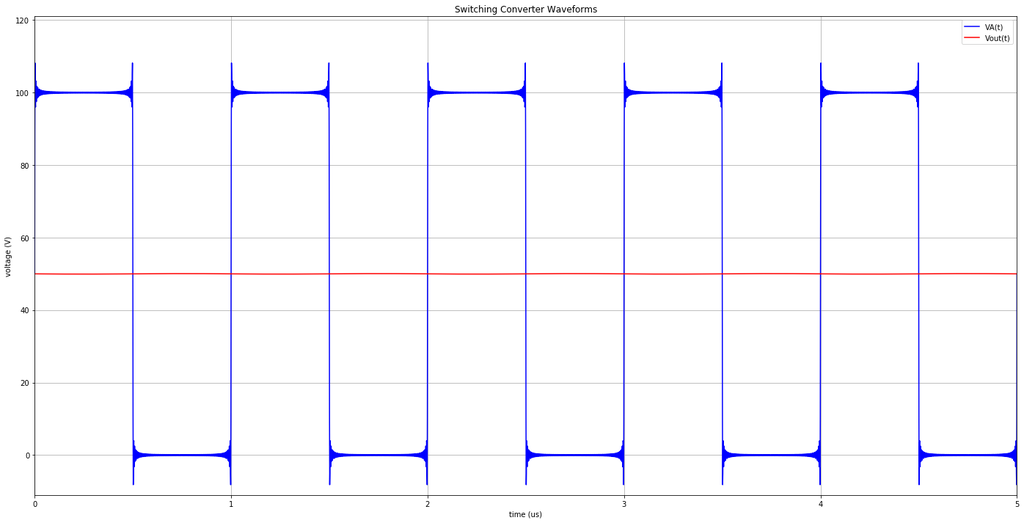

```python
# --------------------------------------------------------------------
# DC-DC Converter Output Filter Example
# --------------------------------------------------------------------
fc = 100e3 # Cutoff frequency (Hz)
L  = 22e-6 # Inductor (H)
C = 1/(L*(2*pi*fc)**2)
print("Filter capacitance C = {0:8.4f} (nF)".format(C/1e-9))

# Decrease output capacitance
C = C/0.1

t = np.arange(0.0, 10e-6, 1e-9) # 10 us sampled at 1 GHz
f = 1.0/1 # frequency (MHz)

# Fourier Series: Square Wave
numHarmonics = 111
VA   = 100

VAt  = VA/2
Vout = VAt
for k in range(1,numHarmonics):
    n = 2*k-1
    VAt  += (2*VA/(n*pi))*sin(2*pi*n*f*1e6*t)
    Vout += (1/(1 - L*C*(2*pi*n*f*1e6)**2))*(2*VA/(n*pi))*sin(2*pi*n*f*1e6*t)

figNum = 1
plt.figure(figNum,figsize=(24,12)) # Figure size in in. x in.
VAt_curve,  = plt.plot(t/1e-6, VAt,  'b')
Vout_curve, = plt.plot(t/1e-6, Vout, 'r')
plt.axis([ 0.0, 5, -11.0, 121 ])
plt.grid(True)
plt.xlabel("time (us)")
plt.ylabel("voltage (V)")
plt.title("Switching Converter Waveforms")
plt.legend([ VAt_curve, Vout_curve ],[ 'VA(t)', 'Vout(t)'])
plt.show()
```